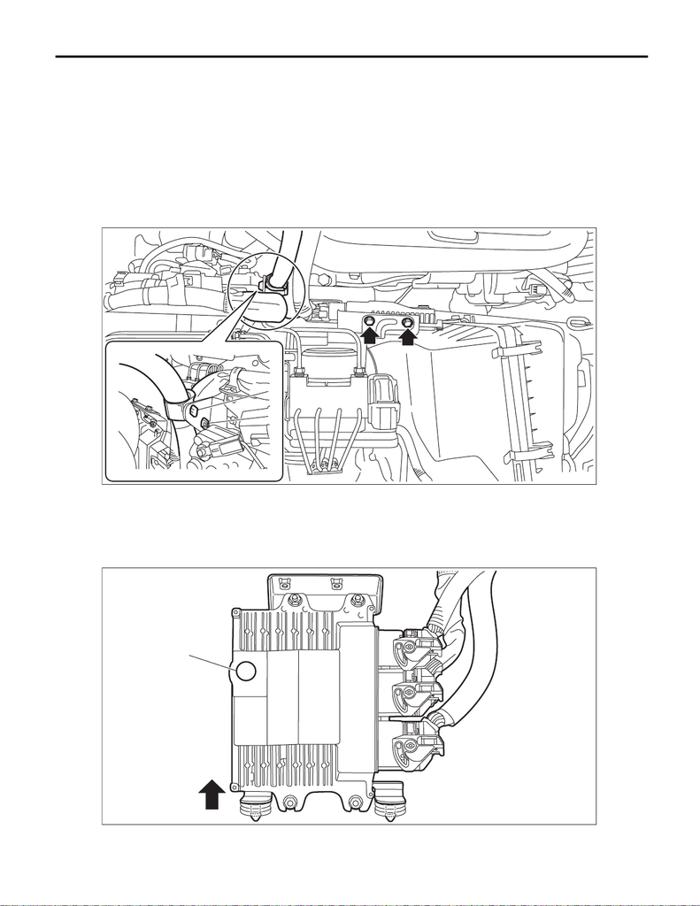

Spark Plug

IGNITION

2. Spark Plug

A: REMOVAL

Spark plug:

Refer to “SPECIFICATION” for spark plug. <Ref. to IG(w/o STI)-2, SPECIFICATION, General De-

scription.>

1. RH SIDE

1) Disconnect the ground terminal from battery sensor. <Ref. to NT-5, BATTERY, NOTE, Note.>

2) Remove the clips (A) and (B) which secure the engine harness and bulkhead harness to the bracket, and

remove the bolt which secures the engine control module (ECM) to the bracket.

3) Pull out the engine control module (ECM) from the bracket, and move it to a location that does not interfere

operation.

NOTE:

When performing the pulling out operation, pay attention not to apply excessive load to the breather filter por-

tion (a) in order to avoid the damage.

IN-03579

(B)

(A)

IN-03580

(a)

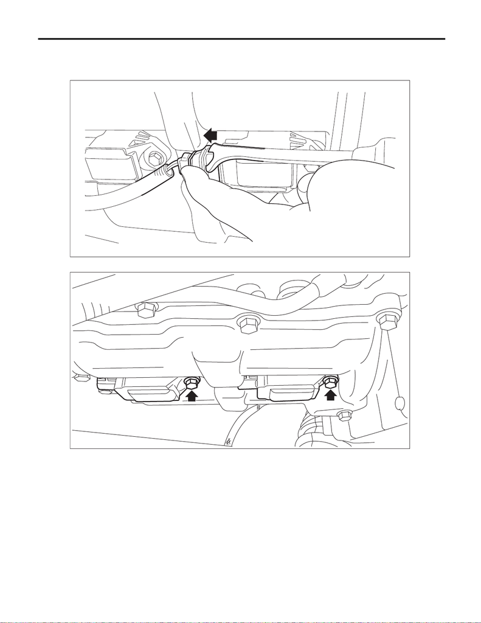

IG(w/o STI)-5

Spark Plug

IGNITION

4) Disconnect the connector from ignition coil.

NOTE:

While pressing the spring (a) shown in the figure, slide it in the direction of the arrow with a clip remover.

5) Remove the ignition coil.

6) Remove the spark plug with a spark plug socket.

IG-02213

(a)

IG-02214

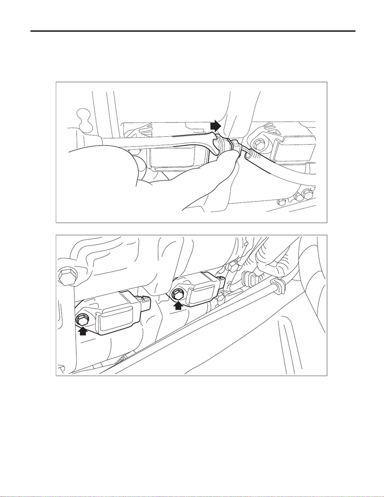

IG(w/o STI)-6

Spark Plug

IGNITION

2. LH SIDE

1) Remove the battery. <Ref. to SC(w/o STI)-50, REMOVAL, Battery.>

2) Disconnect the connector from ignition coil.

NOTE:

While pressing the spring (a) shown in the figure, slide it in the direction of the arrow with a clip remover.

3) Remove the ignition coil.

4) Remove the spark plug with a spark plug socket.

IG-02210

(a)

IG-02212

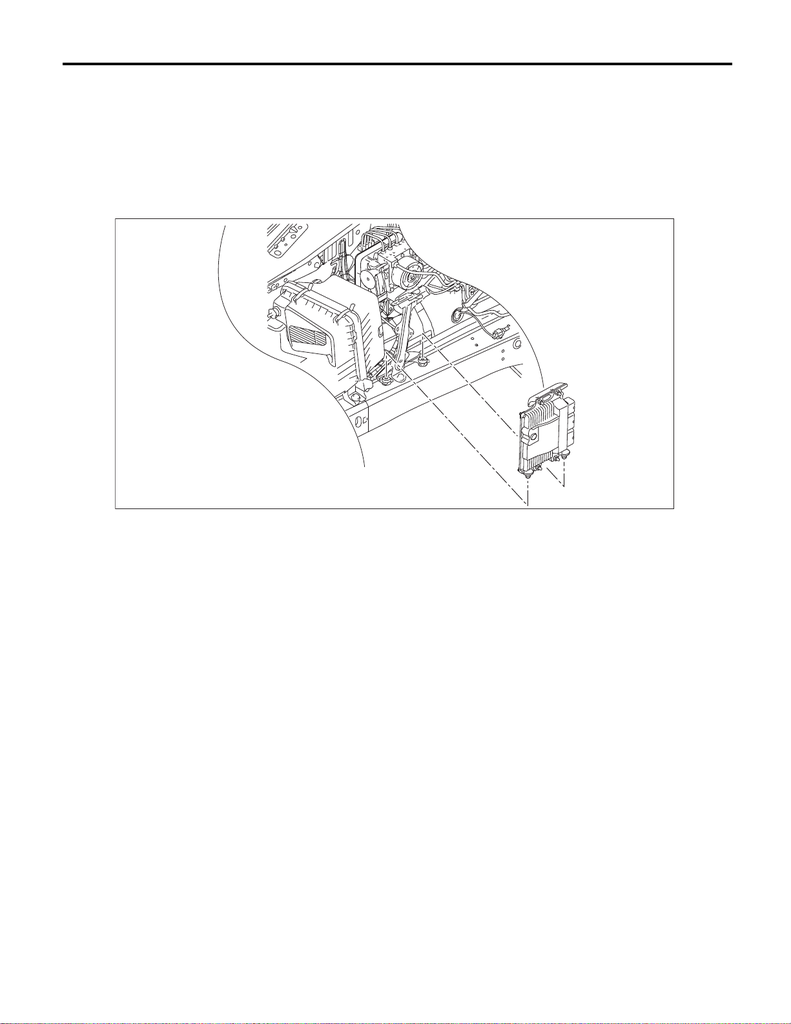

IG(w/o STI)-7

Spark Plug

IGNITION

B: INSTALLATION

1. RH SIDE

Install in the reverse order of removal.

CAUTION:

Degrease the ignition coil fixing portion and the ignition coil mounting bolt.

NOTE:

Insert the engine control module (ECM) to the bracket cushion.

Tightening torque:

Spark plug:

17.5 N·m (1.8 kgf-m, 12.9 ft-lb)

Ignition coil:

8.5 N·m (0.9 kgf-m, 6.3 ft-lb)

2. LH SIDE

Install in the reverse order of removal.

CAUTION:

Degrease the ignition coil fixing portion and the ignition coil mounting bolt.

Tightening torque:

Spark plug:

17.5 N·m (1.8 kgf-m, 12.9 ft-lb)

Ignition coil:

8.5 N·m (0.9 kgf-m, 6.3 ft-lb)

FU-08492

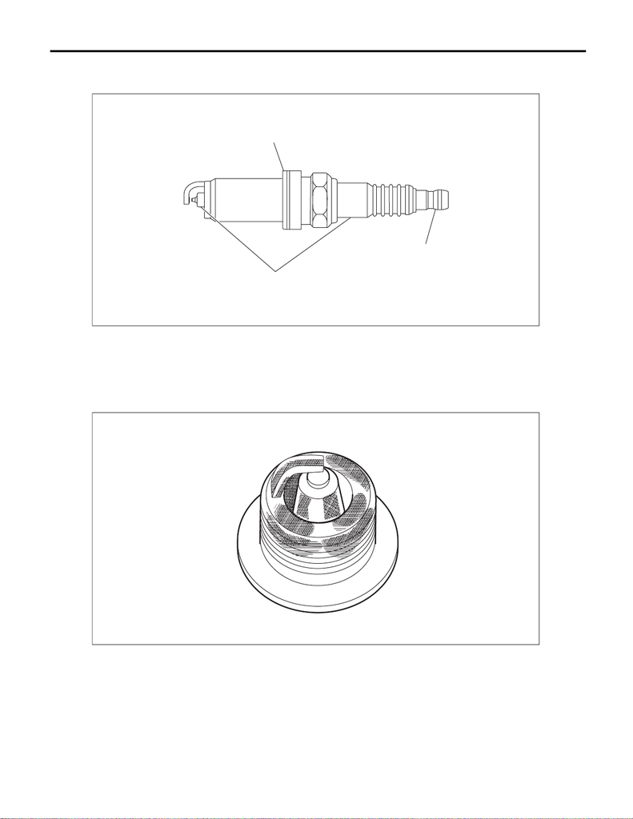

IG(w/o STI)-8

Spark Plug

IGNITION

C: INSPECTION

1) Check the spark plug for abnormalities. If defective, replace the spark plug.

2) Check the spark plug electrode and condition of the insulator. If abnormal, check and repair the cause and

replace the spark plug.

(1) Normal:

Brown to grayish-tan deposits and slight electrode wear indicate correct spark plug heat range.

(A) Terminal damage (B) Crack or damage in insulator (C) Damaged gasket

IG-02166

(C)

(A)

(B)

IG-02135

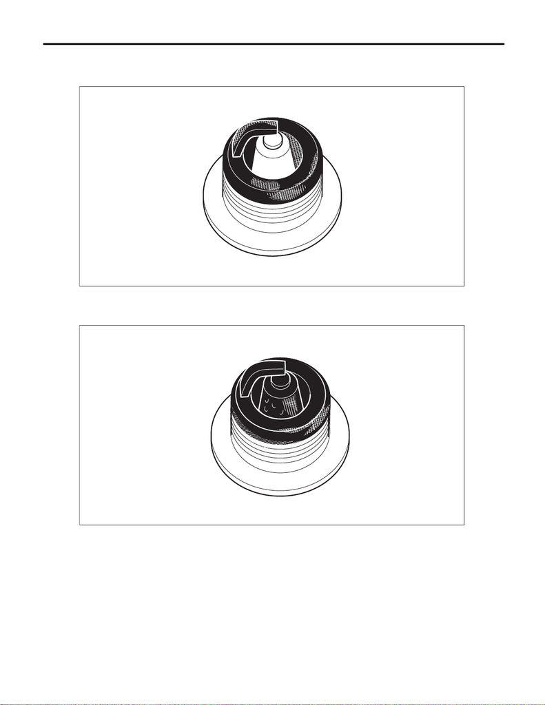

IG(w/o STI)-9

Spark Plug

IGNITION

(2) Carbon fouled:

Dry fluffy carbon deposits on the insulator and electrode are mostly caused by slow-speed driving in town,

weak ignition, too rich fuel mixture, etc.

(3) Oil fouled:

Wet black deposits show oil entrance into combustion chamber through worn piston rings or increased

clearance between valve guides and valve stems.

IG-02136

IG-02137

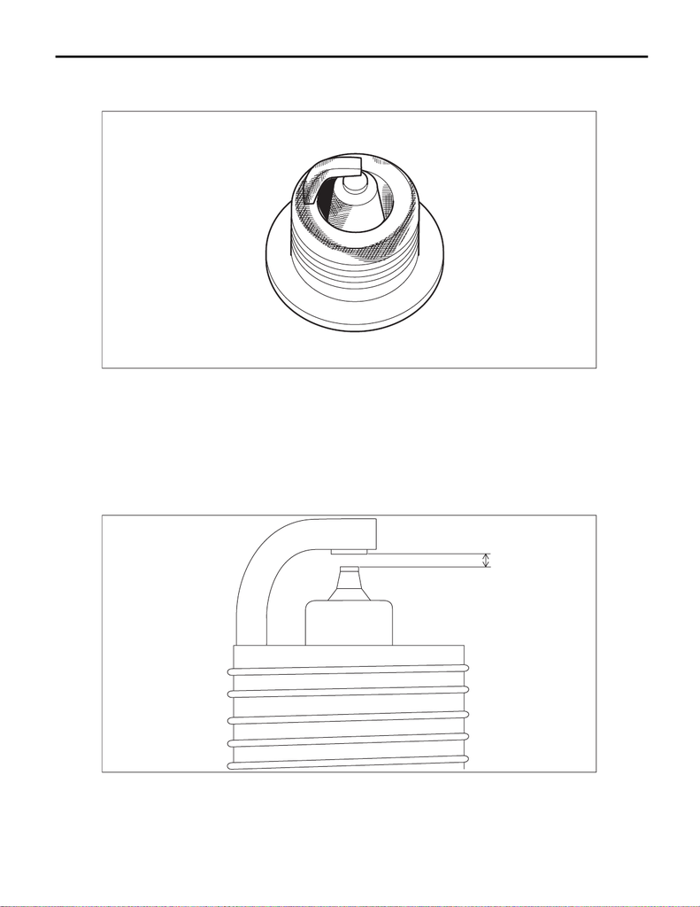

IG(w/o STI)-10

Spark Plug

IGNITION

(4) Overheating:

A white or light gray insulator with black or brown spots and bluish burnt electrodes indicate engine over-

heating, wrong selection of fuel, or loose spark plugs.

3) Using a nylon brush, etc., clean and remove the carbon or oxide deposits from the spark plug. If deposits

are too stubborn, replace the spark plugs. After cleaning the spark plugs, check the spark plug gap “L” using

a gap gauge. If it is not within the standard, replace the spark plug.

NOTE:

• Never use a plug cleaner.

• Do not use a metal brush as it may damage the electrode area.

Spark plug gap L:

Standard

0.50 — 0.55 mm (0.020 — 0.022 in)

IG-02138

IG-02167

L